# Peer-Graded_Assignment_Milestone_Report

Yanyuan Zhu

9/13/2020

## Introduction

The project aims at building a NLP model to predict n-grams. The model shall be embedded into a Shiny App.

This Milestone Report relates to exploratory data analysis regarding the data of [HC Corpora Dataset](https://d396qusza40orc.cloudfront.net/dsscapstone/dataset/Coursera-SwiftKey.zip).

## File summary

The data contains 4 languages (Deutsch, Finnish, Russian and English), each language has 3 sources of input (blogs, news, and twitter), with a tree-like structure as follows

```
##                                    levelName
## 1  ~
## 2   °--Soft
## 3       °--Rtest
## 4           °--JHU_capstone_project_data
## 5               °--final
## 6                   ¦--de_DE
## 7                   ¦   ¦--de_DE.blogs.txt
## 8                   ¦   ¦--de_DE.news.txt
## 9                   ¦   °--de_DE.twitter.txt
## 10                  ¦--fi_FI
## 11                  ¦   ¦--fi_FI.blogs.txt
## 12                  ¦   ¦--fi_FI.news.txt
## 13                  ¦   °--fi_FI.twitter.txt
## 14                  ¦--ru_RU
## 15                  ¦   ¦--ru_RU.blogs.txt
## 16                  ¦   ¦--ru_RU.news.txt
## 17                  ¦   °--ru_RU.twitter.txt
## 18                  °--en_US
## 19                      ¦--en_US.blogs.txt
## 20                      ¦--en_US.news.txt
## 21                      °--en_US.twitter.txt
```

And each input has some lines of words. In sum, there are about 4.3 million line (sentences) of English data, which could be used.

```
##   country  blogs    news twitter
## 1      DE 371440  244743  947774
## 2      FI 439785  485758  285214
## 3      RU 337100  196360  881414
## 4      US 899288 1010242 2360148
```

And the total size, e.g. the english data, is about 550 Mb

```
##   country  blogs   news twitter
## 1      DE   81.5  91.16   72.08
## 2      FI 103.48  89.87   24.16
## 3      RU 111.44 113.48  100.31
## 4      US 200.42 196.28  159.36
```

We are dealing with ~102 Million word counts

```
##   country    blogs     news  twitter
## 1      DE 12653019 13219287 11803491
## 2      FI 12731005 10445964  3152758
## 3      RU  9405378  9115829  9223841
## 4      US 37334131 34372530 30373583
```

## N-grams Frequency Analysis

A visualized, uni-gram word cloud is

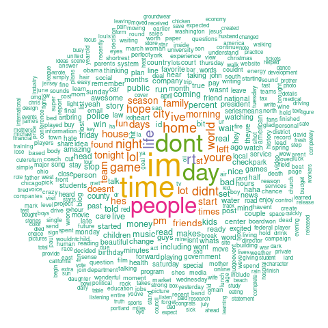

Accordingly, the uni-gram word frequency is

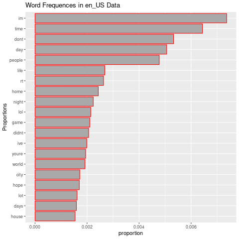

The uni-grams by source (blogs, news, and twitter) are as follows.

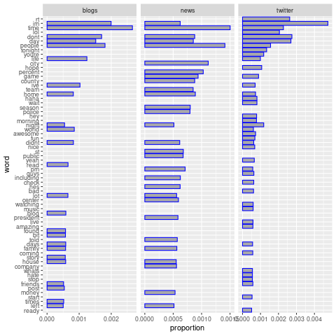

The tri-grams is

[figure not shown]

## Prediction Model: Preliminary Thoughts

The plan is to use the N-grams as the basis for prediction. The use case is: when the use input a word, the model finds the bi-gram/tri-gram even 4-grams with the greatest relative probability accordingly, and show the words to user as candidate.